# SensorTower与AppAnnie游戏下载量准确性对比（基于车类游戏数据）

# 1）API使用函数与指标比较函数（尾页查看）

# 2）平台游戏下载量比较

## 1* 所有游戏下载量数据均为美国地区。

## 2*准确性的判断基于折线图与MAE，MAPE，MSE，RMSE四个统计指标进行。其中折线图部分AA代表App Annie数据，ST代表 SensorTower 数据，true代表该游戏真实下载量（自身打点数据）。比较方法为根据折线图重合程度进行比较。

## 3* 折线图下方是统计指标表。AA行表示App Annie所获得的四个指标值，ST行表示SensorTower所获得的四个指标值。四个统计指标判断标准为指标数值越小代表该网站预测值准确性越高。

# 2.1) Andorid 平台

# 2.1.1Truck them all 游戏下载量比较（2020-10-27----2021-01-06）

```
200
```

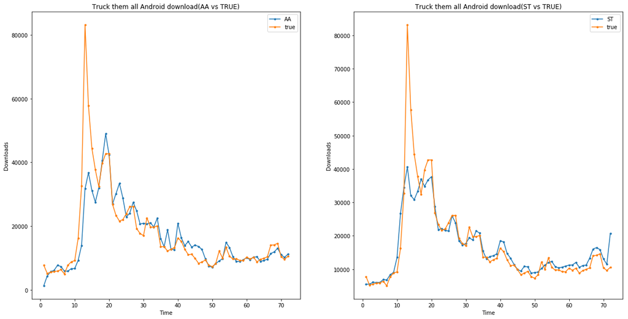

```
  A-Name          MAE      MAPE           MSE         RMSE
0     ST  2983.888889  0.154627  4.395767e+07  6630.058423
1     AA  3535.763889  0.178189  6.062325e+07  7786.093666
```

```python
ta_st = requests_Download_RevenueEstimates('android', 'US', 'daily', '2020-10-27', '2021-1-6', 'www.huolala.truckemall')
ta_true = pd.read_excel('TA_true.xlsx')
ta_true = ta_true[2:]
ta_true = pd.DataFrame(ta_true)
ta_true = ta_true.reset_index(drop=True) # 重置index
ta_st['true'] = ta_true['新增用户数']
ta_AA = pd.read_excel('Android_TA_AA.xlsx')
ta_st['AA'] = ta_AA['Download']
ta_st['count'] = [i for i in range(1, len(ta_st['u']) + 1)]


# subplot(numRows, numCols, plotNum)
#
plt.figure(figsize=(20, 10))

plt.subplot(121)
plt.plot(ta_st['count'], ta_st['AA'], '.-', label='AA')
plt.plot(ta_st['count'], ta_st['true'], '.-', label='true')
plt.title('Truck them all Android download(AA vs TRUE)')
plt.xlabel('Time')
plt.ylabel('Downloads')
plt.legend()

plt.subplot(122)
plt.plot(ta_st['count'], ta_st['u'], '.-', label='ST')
plt.plot(ta_st['count'], ta_st['true'], '.-', label='true')
plt.title('Truck them all Android download(ST vs TRUE)')
plt.xlabel('Time')
plt.ylabel('Downloads')
plt.legend()
plt.show() # 显示图形

print(compare(ta_st['true'], ta_st['u'], ta_st['AA']))
```

### 基于折线图和四个指标，ST 优于 AA。但双平台都未能准确预测在2020年11月8日的峰值。猜测：双平台对于游戏第一次起量且数量较大的预测都不准确。

# 2.1.2 Wheel offroad 游戏下载量比较（2020-12-25---2021-03-01）

```
200
```

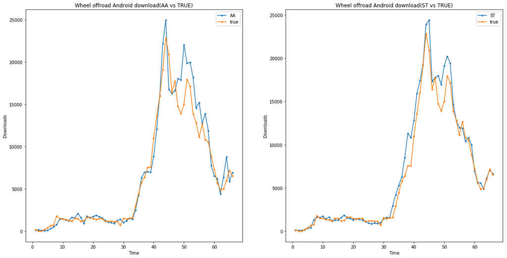

```
  A-Name          MAE      MAPE           MSE         RMSE
0     ST   770.696970  0.634357  1.687693e+06  1299.112249
1     AA  1023.166667  0.773124  2.946179e+06  1716.443579
```

```python
awor_st = requests_Download_RevenueEstimates('android', 'US', 'daily', '2020-12-25', '2021-3-1', 'www.wheelroad.wheeloffroad')
awor_true = pd.read_excel('wheelaoffroad-an.xlsx')
awor_st['true'] = awor_true['下载量']
AWOR_AA = pd.read_excel('Android_WOR_AA.xlsx')
awor_st['AA'] = AWOR_AA['Download']
awor_st['count'] = [i for i in range(1, len(awor_st['u']) + 1)]
awor_st = awor_st[:-1]

# subplot(numRows, numCols, plotNum)
#
plt.figure(figsize=(20, 10))

plt.subplot(121)
plt.plot(awor_st['count'], awor_st['AA'], '.-', label='AA')
plt.plot(awor_st['count'], awor_st['true'], '.-', label='true')
plt.title('Wheel offroad Android download(AA vs TRUE)')
plt.xlabel('Time')
plt.ylabel('Downloads')
plt.legend()

plt.subplot(122)
plt.plot(awor_st['count'], awor_st['u'], '.-', label='ST')
plt.plot(awor_st['count'], awor_st['true'], '.-', label='true')
plt.title('Wheel offroad Android download(ST vs TRUE)')
plt.xlabel('Time')
plt.ylabel('Downloads')
plt.legend()
plt.show() # 显示图形

print(compare(awor_st['true'], awor_st['u'], awor_st['AA']))
```

### 基于折线图和四个指标，ST 优于 AA。

# 2.1.3 Stunt car jumping 游戏下载量比较（2020-11-30---2021-03-01)

```
200
```

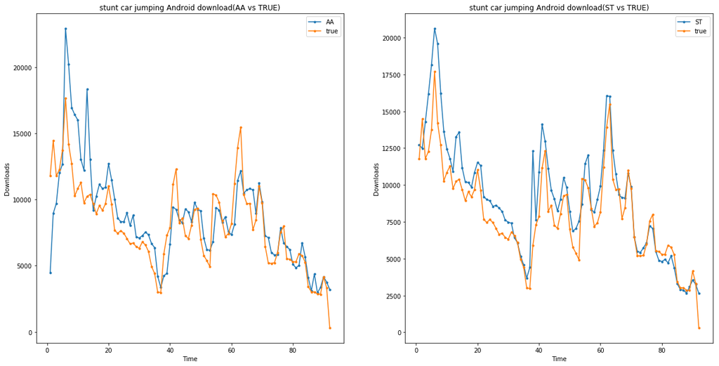

```
  A-Name          MAE      MAPE           MSE         RMSE
0     ST  1312.423913  0.242487  3.146091e+06  1773.722330
1     AA  1617.043478  0.293869  5.250690e+06  2291.438494
```

```python
scj_st = requests_Download_RevenueEstimates('android', 'US', 'daily', '2020-11-30', '2021-3-1', 'www.stunt.stuntcarjumping')
scj_true = pd.read_excel('jetcar3d-an.xlsx')
scj_st['true'] = scj_true['下载量']
SCJ_AA = pd.read_excel('Android_SCJ_AA.xlsx')
scj_st['AA'] = SCJ_AA['Download']
scj_st['count'] = [i for i in range(1, len(scj_st['u']) + 1)]

# subplot(numRows, numCols, plotNum)
#
plt.figure(figsize=(20, 10))

plt.subplot(121)
plt.plot(scj_st['count'], scj_st['AA'], '.-', label='AA')
plt.plot(scj_st['count'], scj_st['true'], '.-', label='true')
plt.title('stunt car jumping Android download(AA vs TRUE)')
plt.xlabel('Time')
plt.ylabel('Downloads')
plt.legend()

plt.subplot(122)
plt.plot(scj_st['count'], scj_st['u'], '.-', label='ST')
plt.plot(scj_st['count'], scj_st['true'], '.-', label='true')
plt.title('stunt car jumping Android download(ST vs TRUE)')
plt.xlabel('Time')
plt.ylabel('Downloads')
plt.legend()
plt.show() # 显示图形

print(compare(scj_st['true'], scj_st['u'], scj_st['AA']))
```

### 基于折线图和四个指标，ST 优于 AA。但双平台都高估了在2020年12月5号出在的峰值。

# 2.1.4 Bang hero 游戏下载量比较（2020-9-29---2021-03-01）

```
200
```

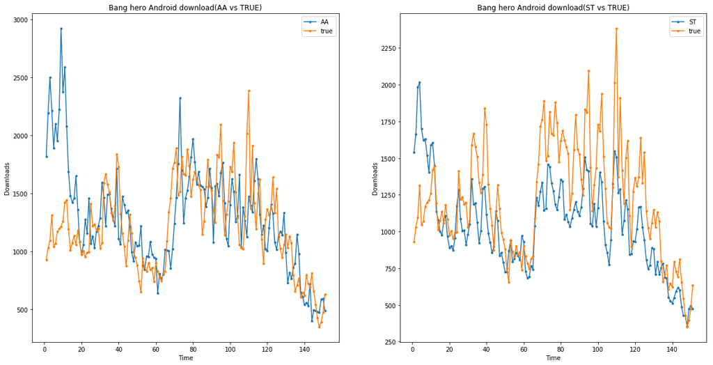

```
  A-Name         MAE      MAPE            MSE        RMSE
0     ST  258.794702  0.199309  107765.788079  328.276999
1     AA  305.350993  0.260664  181476.211921  426.000249
```

```python
bh_st = requests_Download_RevenueEstimates('android', 'US', 'daily', '2020-9-29', '2021-3-1', 'com.mpmf.banghero')
bh_true = pd.read_excel('banghero-an.xlsx')
bh_st['true'] = bh_true['下载量']
BH_AA = pd.read_excel('Android_BH_AA.xlsx')
bh_st['AA'] = BH_AA['Download']
bh_st = bh_st[2:]
bh_st['count'] = [i for i in range(1, len(bh_st['u']) + 1)]
bh_st = bh_st.reset_index(drop=True)
bh_st = bh_st[:-1]
# subplot(numRows, numCols, plotNum)
#
plt.figure(figsize=(20, 10))

plt.subplot(121)
plt.plot(bh_st['count'], bh_st['AA'], '.-', label='AA')
plt.plot(bh_st['count'], bh_st['true'], '.-', label='true')
plt.title('Bang hero Android download(AA vs TRUE)')
plt.xlabel('Time')
plt.ylabel('Downloads')
plt.legend()

plt.subplot(122)
plt.plot(bh_st['count'], bh_st['u'], '.-', label='ST')
plt.plot(bh_st['count'], bh_st['true'], '.-', label='true')
plt.title('Bang hero Android download(ST vs TRUE)')
plt.xlabel('Time')
plt.ylabel('Downloads')
plt.legend()
plt.show() # 显示图形

print(compare(bh_st['true'], bh_st['u'], bh_st['AA']))
```

### 基于折线图和四个指标，ST 优于 AA。但双平台10月初预测都不准确。另外，AA 数据缺损6个，填充方法为k-means(k = 2)

# 2.2) iOS 平台

# 2.2.1 Truck them all 游戏下载量比较（2020-9-29---2021-03-01）

```
200
```

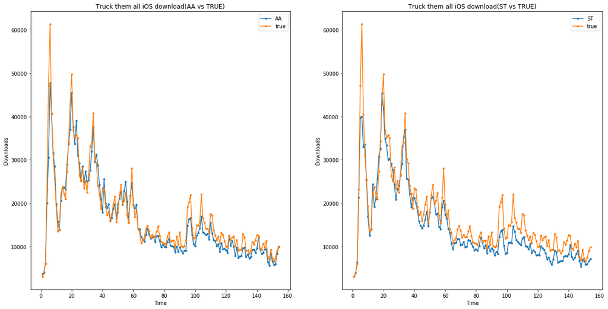

```
  A-Name          MAE      MAPE           MSE         RMSE
0     ST  2805.863636  0.173661  1.281016e+07  3579.128357
1     AA  1842.168831  0.110024  7.224065e+06  2687.762131
```

```python
taios_st = requests_Download_RevenueEstimates('ios', 'US', 'daily', '2020-9-29', '2021-3-1', '1531465966')
taios_st['u'] = taios_st['au'] + taios_st['iu']
taios_true = pd.read_excel('turckemall-ios.xlsx')
# ta_true = ta_true[2:]
# ta_true = pd.DataFrame(ta_true)
# ta_true = ta_true.reset_index(drop=True) # 重置index
taios_st['true'] = taios_true['下载量']
taios_AA = pd.read_excel('iOS_TA_AA.xlsx')
taios_st['AA'] = taios_AA['Download']
taios_st['count'] = [i for i in range(1, len(taios_st['u']) + 1)]


# subplot(numRows, numCols, plotNum)
#
plt.figure(figsize=(20, 10))

plt.subplot(121)
plt.plot(taios_st['count'], taios_st['AA'], '.-', label='AA')
plt.plot(taios_st['count'], taios_st['true'], '.-', label='true')
plt.title('Truck them all iOS download(AA vs TRUE)')
plt.xlabel('Time')
plt.ylabel('Downloads')
plt.legend()

plt.subplot(122)
plt.plot(taios_st['count'], taios_st['u'], '.-', label='ST')
plt.plot(taios_st['count'], taios_st['true'], '.-', label='true')
plt.title('Truck them all iOS download(ST vs TRUE)')
plt.xlabel('Time')
plt.ylabel('Downloads')
plt.legend()
plt.show() # 显示图形

print(compare(taios_st['true'], taios_st['u'], taios_st['AA']))
```

### 基于折线图和四个指标，AA 优于 ST。

### *Truck them all ios下载量 ST vs true (UTC+0)

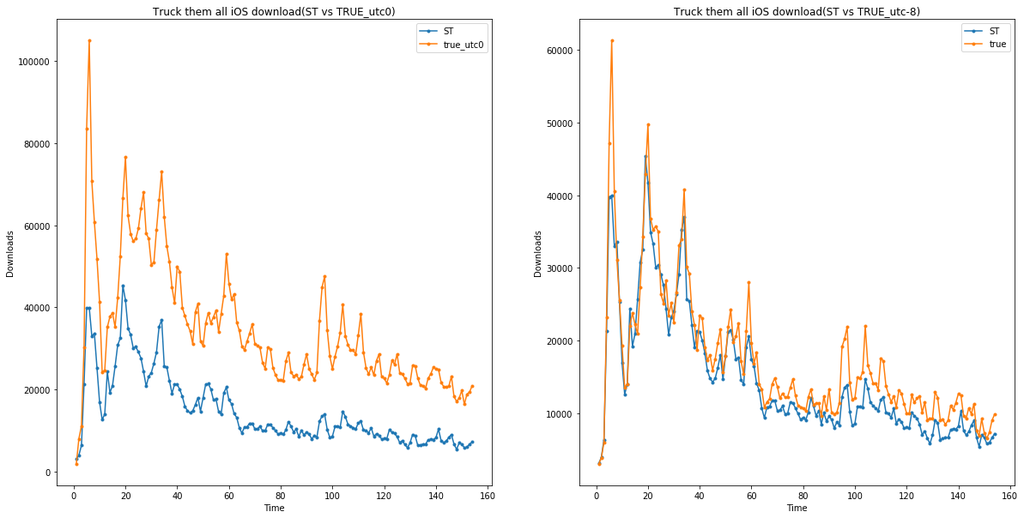

```
  A-Name           MAE      MAPE           MSE         RMSE
0  utc-8   2823.699346  0.225566  1.289385e+07   3590.80041
1   utc0  19992.862745  1.549954  4.646661e+08  21556.11399
```

```python
taios_true_utc0 = pd.read_excel('turckemall_ios_UTC0.xlsx')
taios_st['true_UTC0'] = taios_true_utc0['下载量'][:-1]
# subplot(numRows, numCols, plotNum)
#
plt.figure(figsize=(20, 10))

plt.subplot(121)
plt.plot(taios_st['count'], taios_st['u'], '.-', label='ST')
plt.plot(taios_st['count'], taios_st['true_UTC0'], '.-', label='true_utc0')
plt.title('Truck them all iOS download(ST vs TRUE_utc0)')
plt.xlabel('Time')
plt.ylabel('Downloads')
plt.legend()

plt.subplot(122)
plt.plot(taios_st['count'], taios_st['u'], '.-', label='ST')
plt.plot(taios_st['count'], taios_st['true'], '.-', label='true')
plt.title('Truck them all iOS download(ST vs TRUE_utc-8)')
plt.xlabel('Time')
plt.ylabel('Downloads')
plt.legend()
plt.show() # 显示图形

print(compare_autodefine_name(["utc-8", "utc0"],taios_st['u'][1:], taios_st['true'][1:], taios_st['true_UTC0'][1:])) # 第一行utc-8，第二行utc+0
```

### 考虑SensorTower时区是UTC-8左右而并非UTC+0

# 2.2.2 Crash Race.io 游戏下载量比较（2020-11-30---2021-03-01）

```
200
```

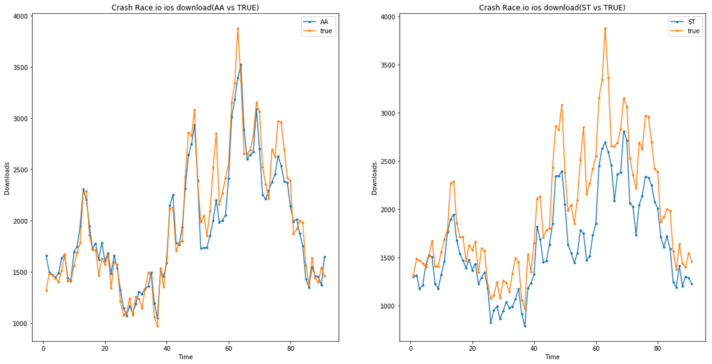

```
  A-Name         MAE      MAPE            MSE        RMSE
0     ST  350.494505  0.169170  172626.824176  415.483843
1     AA  137.351648  0.066881   34161.175824  184.827422
```

```python
cr_st = requests_Download_RevenueEstimates('ios', 'US', 'daily', '2020-11-30', '2021-3-1', '1515691347')
cr_st['u'] = cr_st['au'] + cr_st['iu']
CR_true = pd.read_excel('crashrace.io-ios.xlsx')
cr_st['true'] = CR_true['下载量']
CR_AA = pd.read_excel('iOS_CR_AA.xlsx')
cr_st['AA'] = CR_AA['Download']
cr_st['count'] = [i for i in range(1, 93)]

# subplot(numRows, numCols, plotNum)
#
plt.figure(figsize=(20, 10))

plt.subplot(121)
plt.plot(cr_st['count'][:-1], cr_st['AA'][:-1], '.-', label='AA')
plt.plot(cr_st['count'][:-1], cr_st['true'][:-1], '.-', label='true')
plt.title('Crash Race.io ios download(AA vs TRUE)')
plt.xlabel('Time')
plt.ylabel('Downloads')
plt.legend()

plt.subplot(122)
plt.plot(cr_st['count'][:-1], cr_st['u'][:-1], '.-', label='ST')
plt.plot(cr_st['count'][:-1], cr_st['true'][:-1], '.-', label='true')
plt.title('Crash Race.io ios download(ST vs TRUE)')
plt.xlabel('Time')
plt.ylabel('Downloads')
plt.legend()
plt.show() # 显示图形

print(compare(cr_st['true'][:-1], cr_st['u'][:-1], cr_st['AA'][:-1]))
```

### 基于折线图和四个指标，AA 明显优于 ST。

# 2.2.3 Wheel offroad 游戏下载量比较（2021-02-07---2021-03-01）

```
200
```

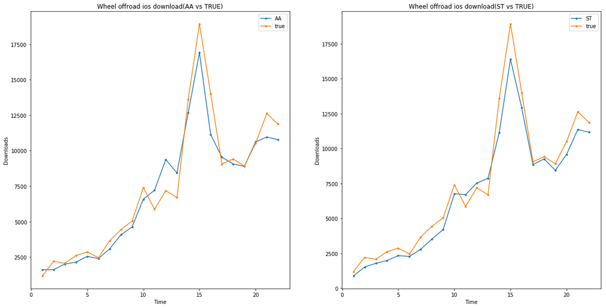

```
  A-Name         MAE      MAPE           MSE         RMSE
0     ST  821.454545  0.136766  1.052603e+06  1025.964203
1     AA  859.909091  0.132373  1.334561e+06  1155.231815
```

```python
wor_st = requests_Download_RevenueEstimates('ios', 'US', 'daily', '2021-2-7', '2021-3-1', '1550052723')
wor_st['u'] = wor_st['au'] + wor_st['iu']
WOR_true = pd.read_excel('wheelaoffroad-ios.xlsx')
wor_st['true'] = WOR_true['下载量']
WOR_AA = pd.read_excel('iOS_WOR_AA.xlsx')
wor_st['AA'] = WOR_AA['Download']
wor_st['count'] = [i for i in range(1, len(wor_st['u']) + 1)]

# subplot(numRows, numCols, plotNum)
#
plt.figure(figsize=(20, 10))

plt.subplot(121)
plt.plot(wor_st['count'][:-1], wor_st['AA'][:-1], '.-', label='AA')
plt.plot(wor_st['count'][:-1], wor_st['true'][:-1], '.-', label='true')
plt.title('Wheel offroad ios download(AA vs TRUE)')
plt.xlabel('Time')
plt.ylabel('Downloads')
plt.legend()

plt.subplot(122)
plt.plot(wor_st['count'][:-1], wor_st['u'][:-1], '.-', label='ST')
plt.plot(wor_st['count'][:-1], wor_st['true'][:-1], '.-', label='true')
plt.title('Wheel offroad ios download(ST vs TRUE)')
plt.xlabel('Time')
plt.ylabel('Downloads')
plt.legend()
plt.show() # 显示图形

print(compare(wor_st['true'][:-1], wor_st['u'][:-1], wor_st['AA'][:-1]))
```

### 基于折线图和四个指标，AA与ST并无明显差异。其可能原因是样本数据量太小。

# 2.2.4 Jet car 3D 游戏下载量比较（2020-11-30---2021-03-01）

```
200
```

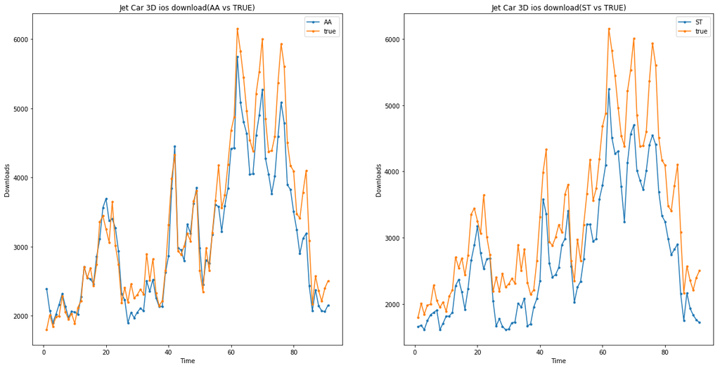

```
  A-Name         MAE      MAPE            MSE        RMSE
0     ST  604.131868  0.179989  464393.648352  681.464341
1     AA  288.802198  0.082077  137497.043956  370.805938
```

```python
jc_st = requests_Download_RevenueEstimates('ios', 'US', 'daily', '2020-11-30', '2021-3-1', '1519399656')
jc_st['u'] = jc_st['au'] + jc_st['iu']

jc_true = pd.read_excel('jetcar3d-ios.xlsx')
jc_st['true'] = jc_true['下载量']

JC_AA = pd.read_excel('iOS_JC_AA.xlsx')
jc_st['AA'] = JC_AA['Download']
jc_st['count'] = [i for i in range(1, len(jc_st['u']) + 1)]

# subplot(numRows, numCols, plotNum)
#
plt.figure(figsize=(20, 10))

plt.subplot(121)
plt.plot(jc_st['count'][:-1], jc_st['AA'][:-1], '.-', label='AA')
plt.plot(jc_st['count'][:-1], jc_st['true'][:-1], '.-', label='true')
plt.title('Jet Car 3D ios download(AA vs TRUE)')
plt.xlabel('Time')
plt.ylabel('Downloads')
plt.legend()

plt.subplot(122)
plt.plot(jc_st['count'][:-1], jc_st['u'][:-1], '.-', label='ST')
plt.plot(jc_st['count'][:-1], jc_st['true'][:-1], '.-', label='true')
plt.title('Jet Car 3D ios download(ST vs TRUE)')
plt.xlabel('Time')
plt.ylabel('Downloads')
plt.legend()
plt.show() # 显示图形

print(compare(jc_st['true'][:-1], jc_st['u'][:-1], jc_st['AA'][:-1]))
```

### 基于折线图和四个指标，AA 明显优于 ST。

# 2.2.5 Bang hero 游戏下载量比较（2020-09-29---2021-02-18）

```
200
```

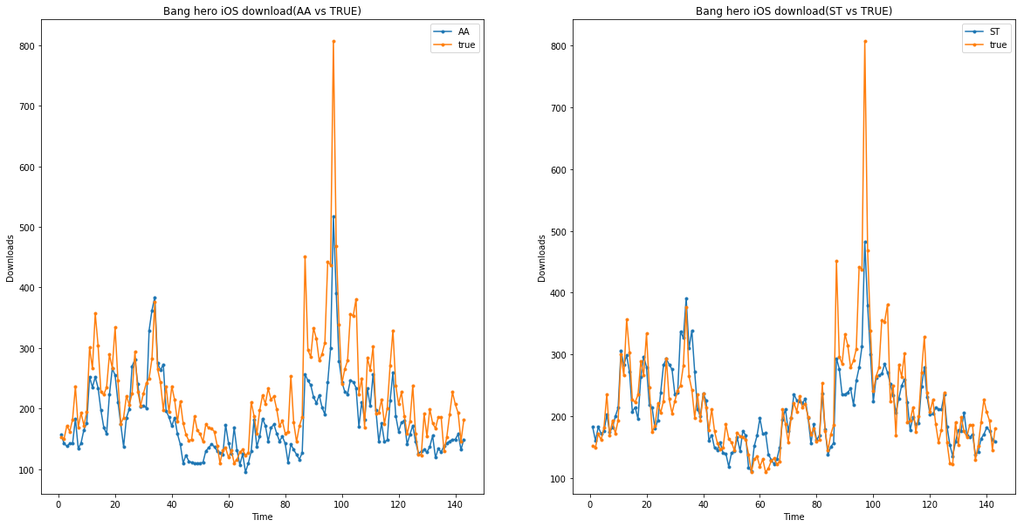

```
  A-Name        MAE      MAPE          MSE       RMSE
0     ST  31.503497  0.133052  2427.041958  49.265018
1     AA  46.615385  0.198090  3773.496503  61.428792
```

```python
bhios_st = requests_Download_RevenueEstimates('ios', 'US', 'daily', '2020-9-29', '2021-2-18', '1516210478')
bhios_st['u'] = bhios_st['au'] + bhios_st['iu']
bhios_true = pd.read_excel('banghero-ios.xlsx')
# ta_true = ta_true[2:]
# ta_true = pd.DataFrame(ta_true)
# ta_true = ta_true.reset_index(drop=True) # 重置index
bhios_st['true'] = bhios_true['下载量']
bhios_AA = pd.read_excel('iOS_BH_AA.xlsx')
bhios_st['AA'] = bhios_AA['Download']
bhios_st['count'] = [i for i in range(1, len(bhios_st['u']) + 1)]


# subplot(numRows, numCols, plotNum)
#
plt.figure(figsize=(20, 10))

plt.subplot(121)
plt.plot(bhios_st['count'], bhios_st['AA'], '.-', label='AA')
plt.plot(bhios_st['count'], bhios_st['true'], '.-', label='true')
plt.title('Bang hero iOS download(AA vs TRUE)')
plt.xlabel('Time')
plt.ylabel('Downloads')
plt.legend()

plt.subplot(122)
plt.plot(bhios_st['count'], bhios_st['u'], '.-', label='ST')
plt.plot(bhios_st['count'], bhios_st['true'], '.-', label='true')
plt.title('Bang hero iOS download(ST vs TRUE)')
plt.xlabel('Time')
plt.ylabel('Downloads')
plt.legend()
plt.show() # 显示图形

print(compare(bhios_st['true'], bhios_st['u'], bhios_st['AA']))
```

### 基于折线图和四个指标，ST 优于 AA。另外，AA 数据缺损11个，填充方法为k-means(k = 2且存在连续缺损值）。过多的缺损值填补可能是导致AA指标不如ST的原因。

# 2.3) iOS + Android

## 2.3.1 Jet car 3D 游戏下载量（2020-11-30---2021-03-01）

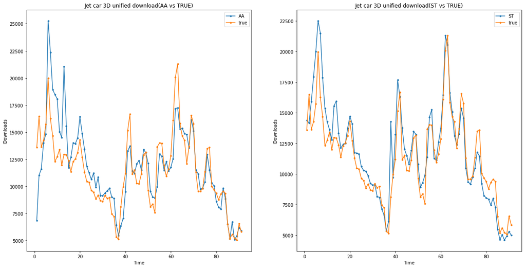

```
  A-Name          MAE      MAPE           MSE         RMSE
0     ST  1206.780220  0.108536  2.652814e+06  1628.746147
1     AA  1596.912088  0.132959  5.248077e+06  2290.868147
```

```python
jc_unified = pd.DataFrame(
        {
            "count": [],
            "jc_true": [],
            "AA_uni": [],
            "ST_uni": []
   })
jc_unified['count'], jc_unified['AA_uni'] =  jc_st['count'], jc_st['AA'] + scj_st['AA']
jc_unified['ST_uni'], jc_unified['jc_true'] = jc_st['u'] + scj_st['u'], jc_st['true']+scj_st['true']

# subplot(numRows, numCols, plotNum)
#
plt.figure(figsize=(20, 10))

plt.subplot(121)
plt.plot(jc_unified['count'][:-1], jc_unified['AA_uni'][:-1], '.-', label='AA')
plt.plot(jc_unified['count'][:-1], jc_unified['jc_true'][:-1], '.-', label='true')
plt.title('Jet car 3D unified download(AA vs TRUE)')
plt.xlabel('Time')
plt.ylabel('Downloads')
plt.legend()

plt.subplot(122)
plt.plot(jc_unified['count'][:-1], jc_unified['ST_uni'][:-1], '.-', label='ST')
plt.plot(jc_unified['count'][:-1], jc_unified['jc_true'][:-1], '.-', label='true')
plt.title('Jet car 3D unified download(ST vs TRUE)')
plt.xlabel('Time')
plt.ylabel('Downloads')
plt.legend()
plt.show() # 显示图形

print(compare(jc_unified['jc_true'][:-1], jc_unified['ST_uni'][:-1], jc_unified['AA_uni'][:-1]))
```

### 基于折线图和四个指标，ST 优于 AA。

# 2.3.2 Truck them all 游戏下载量（2020-10-27----2021-01-06）

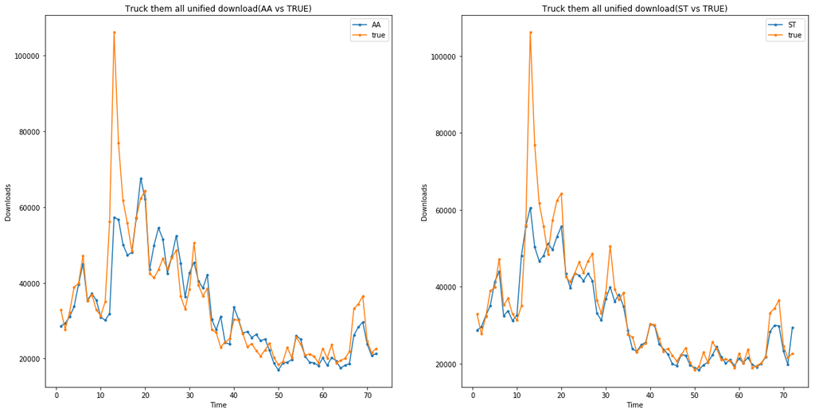

```
  A-Name          MAE      MAPE           MSE         RMSE
0     ST  3630.472222  0.082257  5.521070e+07  7430.390505
1     AA  4053.083333  0.101613  6.197362e+07  7872.332269
```

```python
ta_unified = pd.DataFrame(
        {
            "count": [],
            "ta_true": [],
            "AA_uni": [],
            "ST_uni": []
   })
aux_taios = pd.DataFrame(taios_st[28:100]).reset_index(drop=True) # 重置index
aux_taios.drop(['count'], 1) # delete for columns

ta_unified['count'], ta_unified['AA_uni'] =  ta_st['count'], ta_st['AA'] + aux_taios['AA']
ta_unified['ST_uni'], ta_unified['jc_true'] = ta_st['u'] + aux_taios['u'], ta_st['true'] + aux_taios['true']

# subplot(numRows, numCols, plotNum)
#
plt.figure(figsize=(20, 10))

plt.subplot(121)
plt.plot(ta_unified['count'], ta_unified['AA_uni'], '.-', label='AA')
plt.plot(ta_unified['count'], ta_unified['jc_true'], '.-', label='true')
plt.title('Truck them all unified download(AA vs TRUE)')
plt.xlabel('Time')
plt.ylabel('Downloads')
plt.legend()

plt.subplot(122)
plt.plot(ta_unified['count'], ta_unified['ST_uni'], '.-', label='ST')
plt.plot(ta_unified['count'], ta_unified['jc_true'], '.-', label='true')
plt.title('Truck them all unified download(ST vs TRUE)')
plt.xlabel('Time')
plt.ylabel('Downloads')
plt.legend()
plt.show() # 显示图形

print(compare(ta_unified['jc_true'], ta_unified['ST_uni'], ta_unified['AA_uni']))
```

### 基于折线图和四个指标，ST 优于 AA。

# 2.3.3 Bang hero 游戏下载量（2020-09-29---2021-02-18）

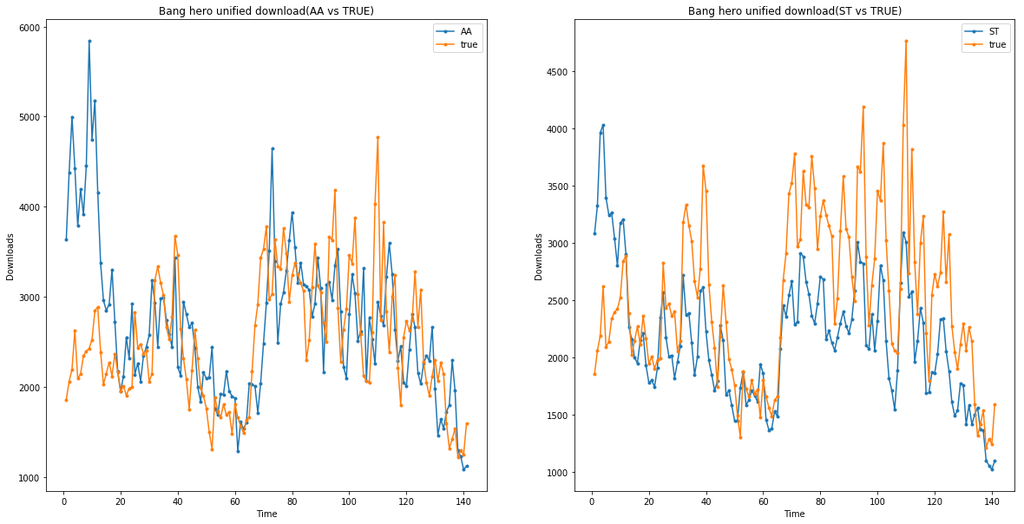

```
  A-Name         MAE      MAPE            MSE        RMSE
0     ST  540.468085  0.202500  457568.709220  676.438252
1     AA  632.992908  0.260633  768126.751773  876.428407
```

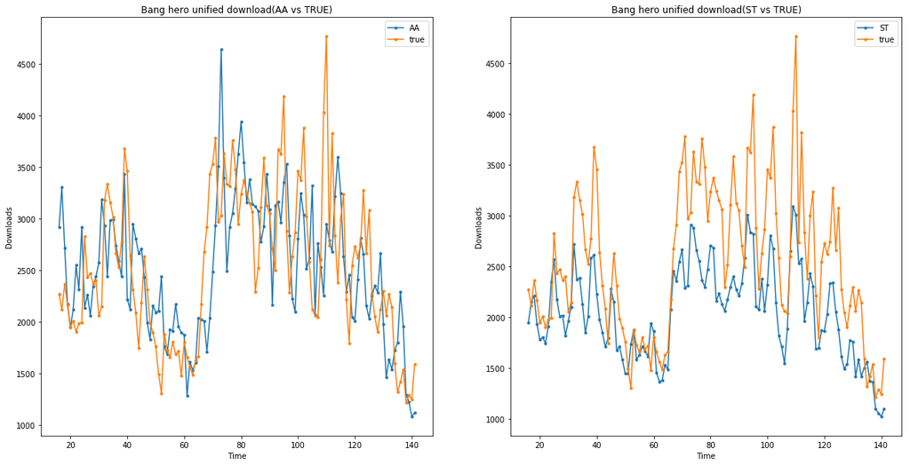

```
  A-Name         MAE      MAPE            MSE        RMSE
0     ST  513.825397  0.185683  407364.412698  638.251058
1     AA  486.492063  0.195612  387493.936508  622.490110
```

```python
bh_unified = pd.DataFrame(
        {
            "count": [],
            "bh_true": [],
            "AA_uni": [],
            "ST_uni": []
   })

bh_st_aux = bh_st[:-10]
bhios_st_aux = bhios_st[2:]
bhios_st_aux = bh_st.reset_index(drop=True)

bh_unified['count'], bh_unified['AA_uni'] =  bh_st_aux['count'], bhios_st_aux['AA'] + bh_st_aux['AA']
bh_unified['ST_uni'], bh_unified['bh_true'] = bh_st_aux['u'] + bhios_st_aux['u'], bh_st_aux['true']+ bhios_st_aux['true']

# subplot(numRows, numCols, plotNum)
#
plt.figure(figsize=(20, 10))

plt.subplot(121)
plt.plot(bh_unified['count'], bh_unified['AA_uni'], '.-', label='AA')
plt.plot(bh_unified['count'], bh_unified['bh_true'], '.-', label='true')
plt.title('Bang hero unified download(AA vs TRUE)')
plt.xlabel('Time')
plt.ylabel('Downloads')
plt.legend()

plt.subplot(122)
plt.plot(bh_unified['count'], bh_unified['ST_uni'], '.-', label='ST')
plt.plot(bh_unified['count'], bh_unified['bh_true'], '.-', label='true')
plt.title('Bang hero unified download(ST vs TRUE)')
plt.xlabel('Time')
plt.ylabel('Downloads')
plt.legend()
plt.show() # 显示图形

print(compare(bh_unified['bh_true'], bh_unified['ST_uni'], bh_unified['AA_uni']))

plt.figure(figsize=(20, 10))

plt.subplot(121)
plt.plot(bh_unified['count'][15:], bh_unified['AA_uni'][15:], '.-', label='AA')
plt.plot(bh_unified['count'][15:], bh_unified['bh_true'][15:], '.-', label='true')
plt.title('Bang hero unified download(AA vs TRUE)')
plt.xlabel('Time')
plt.ylabel('Downloads')
plt.legend()

plt.subplot(122)
plt.plot(bh_unified['count'][15:], bh_unified['ST_uni'][15:], '.-', label='ST')
plt.plot(bh_unified['count'][15:], bh_unified['bh_true'][15:], '.-', label='true')
plt.title('Bang hero unified download(ST vs TRUE)')
plt.xlabel('Time')
plt.ylabel('Downloads')
plt.legend()
plt.show() # 显示图形
print(compare(bh_unified['bh_true'][15:], bh_unified['ST_uni'][15:], bh_unified['AA_uni'][15:]))
```

# 3) 结果与决策

## 3.1 Android平台比较4组数据预测结果均显示SensorTower网站优于AppAnnie（Truck them all，Wheel offroad，Jet car 3D，Bang hero）。

## 3.2 iOS平台比较5组数据预测结果其中3组显示AppAnnie优于SensorTower（Truck them all，Jet car 3D，Crash Race.io）。一组数据显示双平台无显著差异但样本数据量较小（Wheel offroad）。 一组数据显示SensorTower网站优于AppAnnie（Bang hero）。

## 3.3 Unified下载量比较3组数据预测结果其中2组数据显示SensorTower优于AppAnnie（Truck them all，Jet car 3D），一组数据显示AA 优于 ST（Bang hero）。

## 3.4 决策建议，Android平台使用SensorTower，iOS平台使用App Annie，Unified数据使用俩者加和。如果只考虑使用一个平台，建议SensorTower。

```python
# 说明：该部分是API使用函数与比较函数部分，前期准备工作。
# Author： Chen Qian
# Date：2021/03/04

import requests,json
import pandas as pd
import numpy as np
import matplotlib.pyplot as plt
import requests,json
import pandas as pd
import numpy as np
import matplotlib.pyplot as plt



# Functions for getting SensorTower data.
# Store_Intelligence
# Rate Limit: 6 requests per second.
# Requests should be made to the following base URL, followed by the specific path to the API you want to use.
# Latest Updated Date: 2021.03.02
# Author: Chen

# Compact Download / Revenue Estimates ???


# Download / Revenue Estimates for applications (If run error please try https://api.sensortower-china.com:443)

# Input:
# os: Operating System (use "ios", "android",or "unified")
# country: Checking CountryCodes_CategoryIDs to select country (use"WW" for worldwide, "US"  for United States)
# date_granularity: use "daily", "weekly","monthly", or"quarterly",defaults to "daily"
# start_date:(yyyy-mm-dd)
# end_date: (yyyy-mm-dd)
# app_ids: (defaults to None)
# publisher_ids: (defaults to None)
# Do not give both app_ids and publisher_ids at same time.

# Output: A dataframe which containz:

# {
#   "sales_report_estimates_key": {
#     "ios": {
#       "aid": "App ID",
#       "cc": "Country Code",
#       "d": "Date",
#       "iu": "iPhone Downloads",
#       "ir": "iPhone Revenue",
#       "au": "iPad Downloads",
#       "ar": "iPad Revenue"
#     },
#     "android": {
#       "aid": "App ID",
#       "c": "Country Code",
#       "d": "Date",
#       "u": "Android Downloads",
#       "r": "Android Revenue"
#     },
#     "unified": {
#       "app_id": "App ID",
#       "country": "Country Code",
#       "date": "Date",
#       "android_units": "Android Downloads",
#       "android_revenue": "Android Revenue",
#       "ipad_units": "iPad Downloads",
#       "ipad_revenue": "iPad Revenue",
#       "iphone_units": "iPhone Downloads",
#       "iphone_revenue": "iPhone Revenue"
#     }
#   }
# }
# If used publisher_ids, all applications made by this publisher will return.

# Example:
# get_data_apps = requests_Download_RevenueEstimates('ios', 'US', 'daily', '2020-11-01', '2020-11-04', '1531465966')
# get_data_publishers = requests_Download_RevenueEstimates('ios', 'US', 'daily', '2020-11-01', '2020-11-04', publisher_ids = '1191495496')

def requests_Download_RevenueEstimates(os, country, date_granularity, start_date, end_date, app_ids = None, publisher_ids = None):
    if app_ids == None and publisher_ids == None:
        return(print('Error, at least one app ID, or one publisher ID is required.'))

    elif publisher_ids == None:
        aux_DRE = requests.get('https://api.sensortower-china.com/v1/'
                               +os+'/sales_report_estimates?app_ids='+app_ids+
                               '&countries='+country+
                               '&date_granularity='+date_granularity+
                               '&start_date='+
                               start_date+'&end_date='+
                               end_date+'&auth_token=r7cTTJq5nBSqxMU_WmJo'
                               )
    else:
        aux_DRE = requests.get('https://api.sensortower-china.com/v1/'
                               +os+'/sales_report_estimates?publisher_ids='+publisher_ids+
                               '&countries='+country+
                               '&date_granularity='+date_granularity+
                               '&start_date='+
                               start_date+'&end_date='+
                               end_date+'&auth_token=r7cTTJq5nBSqxMU_WmJo'
                               )
    df_DRE = pd.DataFrame(aux_DRE.json())
    print(aux_DRE.status_code)
    return(df_DRE)


# Top Apps(If run error please try https://api.sensortower-china.com:443) for one day, week, month, quarter. 给出指定日期后，会寻找该日期所在的日，周，月，季度，
# Input:
# os: Operating System (use "ios", "android",or "unified")
# comparision_attribute: use "absolute", "delta", or "transformed_delta"
# time_range: use "day","week", "month", or "quarter"
# measure: use "units" or "revenue"
# device_type: use "iphone", "ipad", or "total" for `ios`, leave blank for `android`, use "total" for `unified`
# category: Checking CountryCodes_CategoryIDs to select category.(use 6014 for game applications)
# date: Date.YYYY-MM-DD format.Auto-changes to the beginning of time_range.Ex: Mondays for weeks, 1st of the month, 1st day of the quarter, 1st day of the year.
# country: Checking CountryCodes_CategoryIDs to select country (use"WW" for worldwide, "US"  for United States)
# limit: Limit how many apps per call. (Default: 25, Max: 2000)

# Output: A dataframe which contains informations of top Apps.
# The variable custom_tags contains informations about each application.

# Example_ios_uni:
# https://api.sensortower-china.com/v1/ios/sales_report_estimates_comparison_attributes?comparison_attribute=absolute&time_range=week&measure=units&device_type=total&category=6014&date=2021-02-08&country=US&limit=25&auth_token=r7cTTJq5nBSqxMU_WmJo
# get_week_AppRanking1 = requests_ios_uni_TopApps_periodic('ios', 'absolute', 'week','units', 'total', '6014', '2021-02-08','US','25') # 2021-02-08---2021-02-14
# get_week_AppRanking2 = requests_ios_uni_TopApps_periodic('ios', 'absolute', 'week','units', 'total', '6014', '2021-02-07','US','25') # 2021-02-01---2021-02-7
# get_week_AppRanking3 = requests_ios_uni_TopApps_periodic('ios', 'absolute', 'week','units', 'total', '6014', '2021-02-03','US','25') # 2021-02-01---2021-02-7


# Example_Android:
# https://api.sensortower-china.com/v1/android/sales_report_estimates_comparison_attributes?comparison_attribute=absolute&time_range=week&measure=units&category=game&date=2021-02-08&country=US&limit=25&auth_token=r7cTTJq5nBSqxMU_WmJo
# get_week_ranking4 = requests_Android_TopApps_periodic('android', 'absolute', 'week','units', 'game', '2021-02-08','US','25')

def requests_ios_uni_TopApps_periodic(os,comparision_attribute, time_range, measure, device_type, category, date, country, limit):
    aux_TopApps = requests.get('https://api.sensortower-china.com:443/v1/'
                               +os+'/sales_report_estimates_comparison_attributes?comparison_attribute='+comparision_attribute+
                               '&time_range='+time_range+
                               '&measure='+measure+
                               '&device_type='+device_type+
                               '&category='+category+
                               '&date='+date+
                               '&country='+country+
                               '&limit='+limit+
                               '&auth_token=r7cTTJq5nBSqxMU_WmJo'
                               )
    df_TopApps = pd.DataFrame(aux_TopApps.json())
    print(aux_TopApps.status_code) # Get response messages
    return(df_TopApps)
```

```python
# def requests_TopApps_customized(os,comparision_attribute, measure, device_type, category, date, end_date, country, limit):
#     aux_TopApps = requests.get('https://api.sensortower-china.com:443/v1/'
#                                +os+'/sales_report_estimates_comparison_attributes?comparison_attribute='+comparision_attribute+
#                                '&measure='+measure+
#                                '&device_type='+device_type+
#                                '&category='+category+
#                                '&date='+date+
#                                '&end_date='+end_date+
#                                '&country='+country+
#                                '&limit='+limit+
#                                '&auth_token=r7cTTJq5nBSqxMU_WmJo'
#                                )
#     df_TopApps = pd.DataFrame(aux_TopApps.json())
#     print(aux_TopApps.status_code) # Get response messages
#     return(df_TopApps)


def requests_Android_TopApps_periodic(os,comparision_attribute, time_range, measure, category, date, country, limit):
    aux_TopApps = requests.get('https://api.sensortower-china.com/v1/'
                               +os+'/sales_report_estimates_comparison_attributes?comparison_attribute='+comparision_attribute+
                               '&time_range='+time_range+
                               '&measure='+measure+
                               '&category='+category+
                               '&date='+date+
                               '&country='+country+
                               '&limit='+limit+
                               '&auth_token=r7cTTJq5nBSqxMU_WmJo'
                               )
    df_TopApps = pd.DataFrame(aux_TopApps.json())
    print(aux_TopApps.status_code) # Get response messages
    return(df_TopApps)


# Top Publishers(If run error please try https://api.sensortower-china.com:443) for one day, week, month, quarter. 给出指定日期后，会寻找该日期所在的日，周，月，季度，
# Input:
# os: Operating System (use "ios", "android",or "unified")
# comparision_attribute: use "absolute", "delta", or "transformed_delta"
# time_range: use "day","week", "month", or "quarter"
# measure: use "units" or "revenue"
# device_type: use "iphone", "ipad", or "total" for `ios`, leave blank for `android` and `unified`
# category: Checking CountryCodes_CategoryIDs to select category.(use 6014 for game applications)
# date: Date.YYYY-MM-DD format.Auto-changes to the beginning of time_range.Ex: Mondays for weeks, 1st of the month, 1st day of the quarter, 1st day of the year.
# country: Checking CountryCodes_CategoryIDs to select country (use"WW" for worldwide, "US"  for United States)
# limit: Limit how many apps per call. (Default: 25, Max: 2000)

# Output: A dataframe which contains informations of top Publishers.
# The variable apps contains all informations of applications made by each publisher.

# Example_ios:
# https://api.sensortower-china.com/v1/ios/top_and_trending/publishers?comparison_attribute=absolute&time_range=week&measure=units&device_type=total&category=6014&date=2021-02-08&country=US&limit=25&auth_token=r7cTTJq5nBSqxMU_WmJo
# get_week_PubRanking1_ios = requests_ios_TopPublishers_periodic('ios', 'absolute', 'week','units', 'total', '6014', '2021-02-08','US','25')

# Example_Android_uni:
# https://api.sensortower-china.com/v1/android/top_and_trending/publishers?comparison_attribute=absolute&time_range=week&measure=units&category=6014&date=2021-02-08&country=US&limit=25&auth_token=r7cTTJq5nBSqxMU_WmJo
# get_week_PubRanking1_android = requests_Android_uni_TopPublishers_periodic('android', 'absolute', 'week','units', 'game', '2021-02-08','US','25')

def requests_ios_TopPublishers_periodic(os,comparision_attribute, time_range, measure, device_type, category, date, country, limit):
    aux_TopPublishers = requests.get('https://api.sensortower-china.com/v1/'
                               +os+'/top_and_trending/publishers?comparison_attribute='+comparision_attribute+
                               '&time_range='+time_range+
                               '&measure='+measure+
                               '&device_type='+device_type+
                               '&category='+category+
                               '&date='+date+
                               '&country='+country+
                               '&limit='+limit+
                               '&auth_token=r7cTTJq5nBSqxMU_WmJo'
                               )
    df_TopPublishers = pd.DataFrame(aux_TopPublishers.json())
    print(aux_TopPublishers.status_code) # Get response messages
    return(df_TopPublishers)


def requests_Android_uni_TopPublishers_periodic(os,comparision_attribute, time_range, measure, category, date, country, limit):
    aux_TopPublishers = requests.get('https://api.sensortower-china.com/v1/'
                               +os+'/top_and_trending/publishers?comparison_attribute='+comparision_attribute+
                               '&time_range='+time_range+
                               '&measure='+measure+
                               '&category='+category+
                               '&date='+date+
                               '&country='+country+
                               '&limit='+limit+
                               '&auth_token=r7cTTJq5nBSqxMU_WmJo'
                               )
    df_TopPublishers = pd.DataFrame(aux_TopPublishers.json())
    print(aux_TopPublishers.status_code) # Get response messages
    return(df_TopPublishers)



# Store Summary: Information for all ios or android.
# Input:
# Output:


def requests_Store_Summary(os, category, country, granularity, start_date, end_date):
    aux_SS = requests.get('https://api.sensortower-china.com/v1/'
                               +os+'/store_summary?categories='+category+
                               '&countries='+country+
                               '&date_granularity='+granularity+
                               '&start_date='+start_date+
                               '&end_date='+end_date+
                               '&auth_token=r7cTTJq5nBSqxMU_WmJo'
                               )
    df_SS = pd.DataFrame(aux_SS.json())
    print(aux_SS.status_code) # Get response messages
    return(df_SS)
```

```python
# Game Breakdown: Information for all ios or android.(games specific)
# Input:
# Output:

def requests_Games_Breakdown(os, category, country, granularity, start_date, end_date):
    aux_GB = requests.get('https://api.sensortower-china.com/v1/'
                               +os+'/games_breakdown?categories='+category+
                               '&countries='+country+
                               '&date_granularity='+granularity+
                               '&start_date='+start_date+
                               '&end_date='+end_date+
                               '&auth_token=r7cTTJq5nBSqxMU_WmJo'
                               )
    df_GB = pd.DataFrame(aux_GB.json())
    print(aux_GB.status_code) # Get response messages
    return(df_GB)


# MAE, MAPE, MSE, RMSE


# MAPE(Mean absolute percentage error.)
def MAPE(y_true, y_pred):
    y_true, y_pred = np.array(y_true), np.array(y_pred)
    return np.mean(np.abs((y_true - y_pred) / y_true))

# MSE(Mean squared error.)
def MSE(y_true, y_pred):
    y_true, y_pred = np.array(y_true), np.array(y_pred)
    return np.mean(np.square(y_true - y_pred))


# RMSE(root_mean_square_error.)
def RMSE(y_true, y_pred):
    y_true, y_pred = np.array(y_true), np.array(y_pred)
    return np.sqrt(np.mean(np.square(y_true - y_pred)))

# MAE(Mean absolute error)
def MAE(y_true, y_pred):
    y_true, y_pred = np.array(y_true), np.array(y_pred)
    return np.mean(np.abs((y_true - y_pred)))



def compare(y_true, y_ST_pred, y_AA_pred):
    aux_comparision = pd.DataFrame(
        {   "A-Name": ["ST", "AA"],
            "MAPE": [MAPE(y_true, y_ST_pred), MAPE(y_true, y_AA_pred)],
            "MSE": [MSE(y_true, y_ST_pred), MSE(y_true, y_AA_pred)],
            "RMSE": [RMSE(y_true, y_ST_pred), RMSE(y_true, y_AA_pred)],
            "MAE": [MAE(y_true, y_ST_pred), MAE(y_true, y_AA_pred)]
   })
    return(aux_comparision)

def compare_autodefine_name(auto_name, y_true, y_ST_pred, y_AA_pred):
    aux_comparision = pd.DataFrame(
        {   "A-Name": auto_name,
            "MAPE": [MAPE(y_true, y_ST_pred), MAPE(y_true, y_AA_pred)],
            "MSE": [MSE(y_true, y_ST_pred), MSE(y_true, y_AA_pred)],
            "RMSE": [RMSE(y_true, y_ST_pred), RMSE(y_true, y_AA_pred)],
            "MAE": [MAE(y_true, y_ST_pred), MAE(y_true, y_AA_pred)]
   })
    return(aux_comparision)
```